# PfSPZ DGE on VRC 312 & VRC 314 Datasets

Tuan M. Tran

09/18/2023

## Objective

This markdown doc creates Seq (count) and cpm expression sets for VRC 312 and VRC 314 data, does differential gene expression with edgeR, and outputs to fast GSEA using several different module types (BTMs, MSigDB collections, MonacoMods). Generates fgsea output tables that can be visualized using the “PfSPZ Import VRC 312 314 GSEA IPA for Figures.Rmd” script in “/Volumes/GoogleDrive/My Drive/Tran Lab Shared/Projects/Doris Duke PfSPZ Kenya/Tuan PfSPZ/KenyaPfSPZ/” or on the KSPZV1 github repo.

Notes: 1. For VRC 314, performed analysis on Group 1 (270K x 3 IV), Group 4 & 5 (270K x 4 IV), and Group 6 (900 x 3IV) as these were the groups with same IV dose repeated. 2. Used -log10(p) * sign(logFC) as rank metric for GSEA. 3. Added BSPZV1 study for comparison based on reviewer feedback 4. Use FDR<5% as final filter for visualization 5. Added CAMERA results to complement pre-ranked GSEA results. This was motivated by prior reviewer’s comments that pre-ranked GSEA did not account for inter-gene correlations. Results here show that CAMERA results is similar to pre-ranked GSEA results.

## Baseline Analysis

Run DGE, Camera, pre-ranked fastGSEA for baseline VRC 312 and VRC 314 datasets.

```r
library(doBy)
library(Biobase)
library(biomaRt)
library(edgeR)
library(genefilter)
library(NMF)
library(EDASeq)
library(tweeDEseqCountData)
library(reshape2)
library(tidyverse)
library(googledrive)
library(Microsoft365R)
library(ggplot2)
library(ggpubr)

#Add small legend helper function
addSmallLegend <- function(myPlot, pointSize = 2.5, textSize = 4, spaceLegend = 0.5) {
    myPlot +
        guides(shape = guide_legend(override.aes = list(size = pointSize)),
               color = guide_legend(override.aes = list(size = pointSize))) +
        theme(legend.title = element_text(size = textSize),
              legend.text  = element_text(size = textSize),
              legend.key.size = unit(spaceLegend, "lines"))
}
```

## Read in the VRC 312 and VRC 314 expression sets

Download from google drive.

```r
#VRC 312
temp <- tempfile(fileext = ".rds")
dl <- drive_download(
  as_id("1X139jUTL4lAELEA3eBTZFx2hQgmOPFSZ"), path = temp, overwrite = TRUE)
hdat_312 <- readRDS(file = dl$local_path)
#VRC 314
temp <- tempfile(fileext = ".rds")
dl <- drive_download(
  as_id("1VXTgNSQuWrsA5E-3OgOgJ-AzMZpL4afo"), path = temp, overwrite = TRUE)
hdat_314 <- readRDS(file = dl$local_path)
```

## Set options

```r
myTIMEPOINT <- "Baseline" #"Baseline"

my_VRC312_Group <- "Grp3a3b4a4b4c"
if(my_VRC312_Group == "Grp3a3b4a4b4c"){
  my_VRC312_Groups <- c("3a","3b", "4a","4b", "4c")
  }

my_VRC314_Group <- "Grp1456" #used for final analysis for reasons stated above
PCT <- 100 #used 100 PCT for final analysis

if(my_VRC314_Group == "Grp134567"){
my_VRC314_Groups <- c("Group1","Group3", "Group4","Group5", "Group6", "Group7") # "Group6" #Group2 is IM
}
if(my_VRC314_Group == "Grp567"){
my_VRC314_Groups <- c("Group5", "Group6","Group7")
}
if(my_VRC314_Group == "Grp1456"){
my_VRC314_Groups <- c("Group1", "Group4", "Group5", "Group6")
}
```

### Reduce datasets to relevant samples

```r
hdat_312 <- hdat_312[,which(hdat_312$Dose.group != "EXT")]
hdat_312$Dose.group <- droplevels(hdat_312$Dose.group)

#remove outcome = N/A
hdat_312 <- hdat_312[,!is.na(hdat_312$Outcome.Final)]
hdat_312$Outcome.Final <- droplevels(hdat_312$Outcome.Final)
foo <- hdat_312[,hdat_312$Patient == 331 & grepl("Imm5",hdat_312$Dose.group)] #Remove 331 Imm5 (failed QC)
hdat_312 <- hdat_312[,setdiff(colnames(hdat_312),colnames(foo))]

hdat_312 <- hdat_312[,which(grepl(myTIMEPOINT, hdat_312$Dose.group))]
hdat_312 <- hdat_312[,which(hdat_312$Outcome.Final != "N/A")]
hdat_312$Dose.group <- droplevels(hdat_312$Dose.group)
hdat_312$Outcome.Final <- factor(hdat_312$Outcome.Final)
hdat_312$Outcome.Final <- droplevels(hdat_312$Outcome.Final)

#Filter on Group
hdat_312 <- hdat_312[,which(hdat_312$Group %in% my_VRC312_Groups)]
hdat_312$Group <- factor(hdat_312$Group)
hdat_312$Group <- droplevels(hdat_312$Group)
table(hdat_312$Group,hdat_312$Outcome.Final)
```

```
##
##      Malaria Protected
##   3a       3         0
##   3b       8         1
##   4a       0         2
##   4b       0         4
##   4c       3         6
```

```r
table(hdat_312$Dose.group,hdat_312$Outcome.Final)
```

```
##
##                 Malaria Protected
##   Baseline. D01      14        13
```

[output not shown]

[output not shown]

# VRC 312 Analysis

## Make DGElist object VRC 312

```r
# Make DGElist object
y_VRC312   <- DGEList(count = counts(hdat_312), genes= fData(hdat_312), samples = pData(hdat_312), group= hdat_312$Group, remove.zeros=T)
```

## Filter genes VRC 312

```r
filter.type <- "-low_express_filter-"
dim(y_VRC312)
```

```
## [1] 18580    27
```

```r
#Filter low expression tags: keep genes with at least 1 CPM in at least X, where X is the number of samples in the smallest group (exclude controls by using foo.dat above)
keep <- filterByExpr(y_VRC312)
y_VRC312 <- y_VRC312[keep, , keep.lib.sizes=FALSE]
dim(y_VRC312)
```

```
## [1] 13713    27
```

## Normalization VRC 312

```r
y_VRC312$samples$lib.size <- colSums(y_VRC312$counts)
y_VRC312 <- calcNormFactors(y_VRC312)           #Normalization, use scale (TMM) here or quantile normalization later with voom, but not both
#reference for this here: https://support.bioconductor.org/p/77664/
dim(y_VRC312)
```

```
## [1] 13713    27
```

## Linear modeling VRC 312

Using edgeR with batch adjustment

```r
# create design matrix according to Limma user guide (Ch 9.7 Multi Level Experiments)
# http://www.bioconductor.org/packages/release/bioc/vignettes/limma/inst/doc/usersguide.pdf and
# http://permalink.gmane.org/gmane.science.biology.informatics.conductor/48432
Group   <-   factor(y_VRC312$samples$Group)
Outcome <-   y_VRC312$sample$Outcome.Final
Timept  <-   y_VRC312$sample$Dose.group
Dose    <-   factor(y_VRC312$sample$Dose)
Batch1  <-   factor(y_VRC312$sample$BatchNumber)
Batch2  <-   factor(y_VRC312$sample$Date.Extracted)
Batch   <-   as.factor(paste(as.character(Batch1), as.character(Batch2), sep="_"))
Subject <-   as.factor(as.character(y_VRC312$sample$Patient))
Gender  <-   as.factor(as.character(y_VRC312$sample$Gender))
Outcome_Timept <- factor(paste(Outcome,Timept,sep="_"))
#design <- model.matrix(~0 + Outcome + Batch1 + Batch2) # batch corrected; baseline only
design <- model.matrix(~0 + Gender + Group + Batch1 + Batch2 + Outcome) # dose adjusted; batch corrected; edgeR
#design <- model.matrix(~0 + Outcome_Timept + Dose + Batch1 + Batch2) # batch corrected; dose adjusted; use limma pairing method
rownames(design) <- Subject
colnames(design) <- gsub(":", "_", colnames(design))
colnames(design) <- gsub(". ", "_", colnames(design))
colnames(design) <- gsub("/", "_", colnames(design))
colnames(design) <- gsub("Outcome_Timept", "", colnames(design))
colnames(design) <- gsub("Outcome", "", colnames(design))
colnames(design) <- gsub("Timept", "", colnames(design))
colnames(design) <- gsub("_Dose", "", colnames(design))
design <- design[,!(colSums(design) == 0)]          #remove columns with all zeros

##################################
#Remove Columns not of Full Rank #
##################################
#Error in glmFit.default(sely, design, offset = seloffset, dispersion = 0.05, : Design matrix not of full rank. The following coefficients not estimable: Batch28_18_14 Batch28_6_14
design <- design[,colnames(design)!="Batch28_18_14"]
design <- design[,colnames(design)!="Batch28_6_14"]
colnames(design)
```

```
##  [1] "GenderFemale"  "GenderMale"    "Group3b"       "Group4a"
##  [5] "Group4b"       "Group4c"       "Batch12"       "Batch13"
##  [9] "Batch14"       "Batch15"       "Batch16"       "Batch17"
## [13] "Batch18"       "Batch19"       "Batch27_28_14" "Batch27_30_14"
## [17] "Batch28_11_14" "Batch28_12_14" "Batch28_14_14" "Batch28_4_14"
## [21] "Protected"
```

## Estimate Dispersions VRC 312

```r
y_VRC312 <- estimateDisp(y_VRC312,design)
```

## Perform Differential Gene expression VRC 312

```r
fit <- glmQLFit(y_VRC312, design, robust = TRUE)
qlf <- glmQLFTest(fit, contrast = c(rep(0,(ncol(design)-1)),1))
TopTab_VRC312 <- topTags(qlf, n = nrow(y_VRC312))$table
```

### Examine top 15 DEGs (protected vs not protected) VRC 312

VRC 312 DEGs

```r
TopTab_VRC312 %>%
  arrange(PValue) %>%
  slice_head(., n=15) %>%
  knitr::kable()
```

|  | hgnc_symbol | Gene_length | logFC | logCPM | F | PValue | FDR |
| --- | --- | --- | --- | --- | --- | --- | --- |
| DSP | DSP | 45143 | -7.183389 | 0.7967667 | 30.37105 | 0.0001351 | 0.9992151 |
| MIR3064 | MIR3064 | 66 | 1.664129 | 3.9692527 | 23.30617 | 0.0003663 | 0.9992151 |
| MYOM2 | MYOM2 | 120513 | -3.497329 | 3.9798956 | 22.01934 | 0.0006644 | 0.9992151 |
| KLF4 | KLF4 | 5631 | -1.567225 | 4.9953269 | 19.12717 | 0.0008207 | 0.9992151 |
| GATA2 | GATA2 | 13759 | -2.329341 | 4.4725484 | 19.54625 | 0.0008238 | 0.9992151 |
| KLRC2 | KLRC2 | 15447 | 2.789431 | 0.7660376 | 18.38370 | 0.0009586 | 0.9992151 |
| CPA3 | CPA3 | 31941 | -2.031665 | 3.0558436 | 17.45434 | 0.0011705 | 0.9992151 |
| KLRD1 | KLRD1 | 103543 | 1.479332 | 5.9226770 | 17.06916 | 0.0012741 | 0.9992151 |
| CRIP2 | CRIP2 | 7209 | -2.042987 | 4.2468984 | 16.13106 | 0.0016270 | 0.9992151 |
| N4BP2L2-IT2 | N4BP2L2-IT2 | 4890 | 1.260956 | 3.7626414 | 15.52629 | 0.0018113 | 0.9992151 |
| DEFA4 | DEFA4 | 2517 | 2.021364 | 2.9653200 | 14.91959 | 0.0020920 | 0.9992151 |
| FLVCR1-AS1 | FLVCR1-AS1 | 5981 | -2.348873 | 1.5393094 | 14.84552 | 0.0021297 | 0.9992151 |
| LIMS2 | LIMS2 | 43406 | -1.511498 | 3.2091759 | 14.37374 | 0.0023888 | 0.9992151 |
| GZMH | GZMH | 3220 | 1.712349 | 5.9327718 | 14.42462 | 0.0023979 | 0.9992151 |
| CLEC1A | CLEC1A | 42074 | 2.205862 | 1.2225068 | 14.18275 | 0.0025040 | 0.9992151 |

## Camera VRC 312

### Competitive gene set test accounting for inter-gene correlation between “protected” vs “not protected” VRC 312

Uses Camera: https://academic.oup.com/nar/article/40/17/e133/2411151

```r
mymodules <- c("highBTMs", "lowBTMs", "MonacoModules", "BloodGen3Module", "MSigDB_Hallmark_v7.4")
cameratab_list <- vector("list", length(mymodules))
names(cameratab_list) <- mymodules
for(i in mymodules){
  url <- paste0("https://github.com/TranLab/ModuleLists/blob/main/", i, ".rds?raw=true")
  temp_list <- readRDS(url(url, method="libcurl"))
  temp_indices <- ids2indices(temp_list, y_VRC312$genes$hgnc_symbol)
  cameratab <- camera(y_VRC312, temp_indices, design, contrast =  c(rep(0,(ncol(design)-1)),1), inter.gene.cor=0.01)
  cameratab_list[[i]] <- cameratab %>%
    rownames_to_column(var = "module")
}
cameratab_bind_VRC312 <- bind_rows(cameratab_list, .id = "module_type") %>%
  mutate(study = "VRC312") %>%
  dplyr::select(study, module_type, module, everything())
```

### Plot CAMERA results VRC 312

```r
#plotting options
basetextsize <- 12
myfont <- "Helvetica"
bubble_max_size <- 15

myCameraPlotDat_VRC312 <- cameratab_bind_VRC312 %>%
  filter(module_type %in% c("highBTMs", "lowBTMs", "MonacoModules", "BloodGen3Module", "MSigDB_Hallmark_v7.4"))  %>%
  #filter(!grepl("TBA", module)) %>%
  dplyr::select(study, module_type, module, NGenes, Direction, FDR) %>%
  mutate(neglogpadj = -log10(FDR)) %>%
  mutate(fdr_direction = ifelse(Direction == "Up", neglogpadj*1, neglogpadj*-1)) %>%
  mutate(module = gsub("gd", "γδ", module)) %>%
  mutate(module = gsub("Vd2", "Vδ2", module)) %>%
  mutate(module = gsub("Vg", "Vγ", module)) %>%
  mutate(module = gsub("HALLMARK_", "", module)) %>%
  mutate(module = gsub("_", " ", module)) %>%
  mutate(module = sub(".*?\\_", "", module)) %>%
  mutate(module = fct_reorder(module, fdr_direction, .desc = TRUE)) %>%
  filter(!grepl("TBD", module)) %>%
  mutate(module_type = factor(module_type, levels = c("highBTMs", "MonacoModules", "lowBTMs", "MSigDB_Hallmark_v7.4", "BloodGen3Module"))) %>%
  arrange(desc(neglogpadj)) %>%
  droplevels() %>%
  filter(FDR < 0.05) %>%
  dplyr::select(study, module_type, module, everything())

#saveRDS(myCameraPlotDat_VRC312, paste0(datadir, "VRC312_Camera_PvNP_FDR5.rds"))
```

### Apply GSEA VRC 312

Rank genes by -log10(PValue)*sign(logFC). Run fgsea from fgsea package using NamedGeneRankList2GseaTable helper function.

```r
set.seed(23)
ranks_VRC312 <- TopTab_VRC312 %>%
  mutate(rankmetric = -log10(.$PValue)*sign(.$logFC)) %>%
  dplyr::select(hgnc_symbol,rankmetric) %>%
  na.omit() %>%
  distinct() %>%
  group_by(hgnc_symbol) %>%
  summarize(rankmetric = mean(rankmetric)) %>%
  arrange(desc(rankmetric)) %>%
  deframe()

#Run fgsea from fgsea package using NamedGeneRankList2GseaTable helper function
devtools::source_url("https://github.com/TranLab/ModuleLists/blob/main/NamedGeneRankList2GseaTable.R?raw=TRUE")
GSEAtab_VRC312 <- NamedGeneRankList2GseaTable(rankedgenes = ranks_VRC312,
                                       geneset = "all",
                                       output_directory = tempdir(),
                                       filename_prefix = "GSEA",
                                       sampleSize = 101,
                                       minSize = 20,
                                       maxSize = Inf,
                                       scoreType = "std") %>%
  as_tibble() %>%
  arrange(desc(NES)) %>%
  mutate(study = "VRC312") %>%
  dplyr::select(study, module_type, pathway, ES, NES, size, leadingEdge, pval, padj) %>%
  mutate(leadingEdge = gsub("^c\\(|\\)$", "", leadingEdge)) %>%
  mutate(leadingEdge = gsub('"', "", leadingEdge)) %>%
  arrange(padj)
```

```
## [1] "Running fgsea for MonacoModules signatures"
## [1] "Running fgsea for highBTMs signatures"
## [1] "Running fgsea for lowBTMs signatures"
## [1] "Running fgsea for BloodGen3Module signatures"
## [1] "Running fgsea for MSigDB_Hallmark_v7.4 signatures"
## [1] "Running fgsea for MSigDB_C2_biocarta_v7.4 signatures"
## [1] "Running fgsea for MSigDB_C2_kegg_v7.4 signatures"
## [1] "Running fgsea for MSigDB_C8_all_v7.4 signatures"
## [1] "Running fgsea for MSigDB_C7_all_v7.4 signatures"
## [1] "Running fgsea for MSigDB_C5_GO_bp_v7.4 signatures"
## [1] "Running fgsea for MSigDB_C5_GO_mf_v7.4 signatures"
```

```r
#saveRDS(GSEAtab_VRC312, paste0(datadir, "VRC312_GSEA_PvNP_FDR5.rds"))
```

# VRC 314 Analysis

## Make DGElist object VRC 314

```r
y_VRC314   <- DGEList(count = counts(hdat_314), genes= fData(hdat_314), samples = pData(hdat_314),group= hdat_314$Outcome.Final, remove.zeros=T)
```

## Filter genes VRC 314

```r
filter.type <- "-low_express_filter-"
dim(y_VRC314)
```

```
## [1] 17699    34
```

```r
#Filter low expression tags: keep genes with at least 1 CPM in at least X, where X is the number of samples in the smallest group (exclude controls by using foo.dat above)
keep <- filterByExpr(y_VRC314, group = hdat_314$Outcome.Final)
y_VRC314 <- y_VRC314[keep, , keep.lib.sizes=FALSE]
dim(y_VRC314)
```

```
## [1] 12059    34
```

## Normalization VRC 314

```r
###############
y_VRC314$samples$lib.size <- colSums(y_VRC314$counts)
y_VRC314 <- calcNormFactors(y_VRC314)           #Normalization, use scale (TMM) here or quantile normalization later with voom, but not both
#reference for this here: https://support.bioconductor.org/p/77664/
dim(y_VRC314)
```

```
## [1] 12059    34
```

```r
logcpm_314 <- cpm(y_VRC314, prior.count = 0.25,log=T)
```

## Filter by library size VRC 314

Note that expression set already has been filtered.

```r
y_VRC314 <- y_VRC314[,y_VRC314$samples$lib.size>7.5e6]
```

## Linear modeling VRC 314

Use edgeR with batch adjustment

```r
# create design matrix according to Limma user guide (Ch 9.7 Multi Level Experiments)
# http://www.bioconductor.org/packages/release/bioc/vignettes/limma/inst/doc/usersguide.pdf and
# http://permalink.gmane.org/gmane.science.biology.informatics.conductor/48432

Outcome <- y_VRC314$samples$Outcome.Final
Timept <- y_VRC314$samples$Dose.group
Sex <- factor(y_VRC314$samples$Gender)
Batch1  <-   factor(y_VRC314$samples$Lib_Batch)
Batch2  <-   factor(y_VRC314$samples$Date)
Batch   <-   as.factor(paste(as.character(Batch1), as.character(Batch2), sep="_"))
Group <- factor(y_VRC314$samples$Group)
Subject <-   y_VRC314$samples$Patient
Outcome_Timept <- factor(paste(Outcome,Timept,sep="_"))
design <- model.matrix(~0 + Group + Sex + Batch + Outcome) # GROUP and BATCH corrected
rownames(design) <- Subject
colnames(design) <- gsub(":", "_", colnames(design))
colnames(design) <- gsub("\\.", "_", colnames(design))
colnames(design) <- gsub(", ", "_", colnames(design))
colnames(design) <- gsub(" \\+ ", "_", colnames(design))
colnames(design) <- gsub("CHMI 1", "CHMI1", colnames(design))
colnames(design) <- gsub(" ", "_", colnames(design))
colnames(design) <- gsub("Outcome_Timept", "", colnames(design))
colnames(design) <- gsub("Outcome", "", colnames(design))
colnames(design) <- gsub("Timept", "", colnames(design))
design <- design[,!(colSums(design) == 0)]          #remove columns with all zeros

# When running myGroup = Grp1456
# Design matrix not of full rank.  The following coefficients not estimable:
#  Batch4_Jun_27_2016 Batch5_March_23_2016 Batch5_Nov_24_2015
#for Grp
if(my_VRC314_Group == "Grp1456"){
  design <- design[,!colnames(design)%in%c("Batch4_Jun_27_2016", "Batch5_March_23_2016", "Batch5_Nov_24_2015")]
}
colnames(design)
```

```
##  [1] "GroupGroup1"          "GroupGroup4"          "GroupGroup5"
##  [4] "GroupGroup6"          "SexMale"              "Batch1_Jun_27_2016"
##  [7] "Batch1_March_23_2016" "Batch2_Dec_14_2015"   "Batch2_Feb_15_2016"
## [10] "Batch2_Jun_27_2016"   "Batch2_March_22_2016" "Batch2_March_23_2016"
## [13] "Batch3_Dec_14_2015"   "Batch3_Feb_15_2016"   "Batch3_March_22_2016"
## [16] "Batch3_March_23_2016" "Batch4_Feb_15_2016"   "Batch4_March_23_2016"
## [19] "Batch5_Feb_15_2016"   "Batch5_Jan_10_2017"   "Batch5_Nov_23_2015"
## [22] "Protected"
```

## Estimate Dispersions VRC 314

```r
y_VRC314 <- estimateDisp(y_VRC314, design)
```

## Perform Differential Gene expression VRC 314

```r
fit <- glmQLFit(y_VRC314, design, robust = TRUE)
qlf <- glmQLFTest(fit, contrast = c(rep(0,(ncol(design)-1)),1))
TopTab_VRC314 <- topTags(qlf, n = nrow(y_VRC314))$table
```

### Examine top 15 DEGs (protected vs not protected) VRC 314

VRC 314 DEGs

```r
TopTab_VRC314 %>%
  arrange(PValue) %>%
  slice_head(., n=15) %>%
  knitr::kable()
```

|  | hgnc_symbol | Gene_length | logFC | logCPM | F | PValue | FDR |
| --- | --- | --- | --- | --- | --- | --- | --- |
| LSM3 | LSM3 | 22762 | 1.2534945 | 2.0450348 | 19.02542 | 0.0003816 | 0.9995008 |
| RSL24D1 | RSL24D1 | 16262 | 0.8916864 | 4.1146619 | 18.79948 | 0.0004041 | 0.9995008 |
| MRPL22 | MRPL22 | 28342 | 0.8539825 | 2.0954515 | 18.30556 | 0.0004587 | 0.9995008 |
| HMGB2 | HMGB2 | 3431 | 0.5954213 | 5.9447479 | 18.23662 | 0.0004670 | 0.9995008 |
| PKMYT1 | PKMYT1 | 12516 | 1.3627389 | 0.9853329 | 17.67822 | 0.0005402 | 0.9995008 |
| RPAP2 | RPAP2 | 103092 | 0.6424314 | 2.6740872 | 16.65790 | 0.0007097 | 0.9995008 |
| LRRN3 | LRRN3 | 34449 | 0.5701528 | 5.0630690 | 16.03700 | 0.0008415 | 0.9995008 |
| ERH | ERH | 18505 | 0.5006289 | 4.9424513 | 15.49000 | 0.0009806 | 0.9995008 |
| TOP2A | TOP2A | 29435 | 1.1330862 | 2.0631916 | 15.36119 | 0.0010169 | 0.9995008 |
| EIF3E | EIF3E | 234118 | 0.5347341 | 5.5085325 | 15.14272 | 0.0010821 | 0.9995008 |
| HAT1 | HAT1 | 61235 | 0.7044486 | 3.7125303 | 14.90245 | 0.0011592 | 0.9995008 |
| RPF1 | RPF1 | 18532 | 0.4450407 | 4.3677015 | 14.53970 | 0.0012876 | 0.9995008 |
| TNFRSF17 | TNFRSF17 | 2962 | 1.0589016 | 2.0137156 | 14.42307 | 0.0013322 | 0.9995008 |
| KIAA0391 | KIAA0391 | 155769 | 0.4018734 | 4.9269749 | 14.26914 | 0.0013937 | 0.9995008 |
| RPL23P8 | RPL23P8 | 428 | 1.1001535 | 3.3326897 | 13.87118 | 0.0016220 | 0.9995008 |

## Camera VRC 314

### Competitive gene set test accounting for inter-gene correlation between “protected” vs “not protected” VRC 314

Uses Camera: https://academic.oup.com/nar/article/40/17/e133/2411151

```r
mymodules <- c("highBTMs", "lowBTMs", "MonacoModules", "BloodGen3Module", "MSigDB_Hallmark_v7.4")
cameratab_list <- vector("list", length(mymodules))
names(cameratab_list) <- mymodules
for(i in mymodules){
  url <- paste0("https://github.com/TranLab/ModuleLists/blob/main/", i, ".rds?raw=true")
  temp_list <- readRDS(url(url, method="libcurl"))
  temp_indices <- ids2indices(temp_list, y_VRC314$genes$hgnc_symbol)
  cameratab <- camera(y_VRC314, temp_indices, design, contrast =  c(rep(0,(ncol(design)-1)),1), inter.gene.cor=0.01)
  cameratab_list[[i]] <- cameratab %>%
    rownames_to_column(var = "module")
}
cameratab_bind_VRC314 <- bind_rows(cameratab_list, .id = "module_type") %>%
  mutate(study = "VRC314") %>%
  dplyr::select(study, module_type, module, everything())
```

### Plot CAMERA results VRC 314

```r
#plotting options
basetextsize <- 12
myfont <- "Helvetica"
bubble_max_size <- 15

myCameraPlotDat_VRC314 <- cameratab_bind_VRC314 %>%
  filter(module_type %in% c("highBTMs", "lowBTMs", "MonacoModules", "BloodGen3Module", "MSigDB_Hallmark_v7.4"))  %>%
  #filter(!grepl("TBA", module)) %>%
  dplyr::select(study, module_type, module, NGenes, Direction, FDR) %>%
  mutate(neglogpadj = -log10(FDR)) %>%
  mutate(fdr_direction = ifelse(Direction == "Up", neglogpadj*1, neglogpadj*-1)) %>%
  mutate(module = gsub("gd", "γδ", module)) %>%
  mutate(module = gsub("Vd2", "Vδ2", module)) %>%
  mutate(module = gsub("Vg", "Vγ", module)) %>%
  mutate(module = gsub("HALLMARK_", "", module)) %>%
  mutate(module = gsub("_", " ", module)) %>%
  mutate(module = sub(".*?\\_", "", module)) %>%
  mutate(module = fct_reorder(module, fdr_direction, .desc = TRUE)) %>%
  filter(!grepl("TBD", module)) %>%
  mutate(module_type = factor(module_type, levels = c("highBTMs", "MonacoModules", "lowBTMs", "MSigDB_Hallmark_v7.4", "BloodGen3Module"))) %>%
  arrange(desc(neglogpadj)) %>%
  droplevels() %>%
  filter(FDR < 0.05) %>%
  dplyr::select(study, module_type, module, everything())

#saveRDS(myCameraPlotDat_VRC314, paste0(datadir, "VRC314_Camera_PvNP_FDR5.rds"))
```

### Apply GSEA VRC 314

Rank genes by -log10(PValue)*sign(logFC). Run fgsea from fgsea package using NamedGeneRankList2GseaTable helper function.

```r
set.seed(23)
ranks_VRC314 <- TopTab_VRC314 %>%
  mutate(rankmetric = -log10(.$PValue)*sign(.$logFC)) %>%
  dplyr::select(hgnc_symbol,rankmetric) %>%
  na.omit() %>%
  distinct() %>%
  group_by(hgnc_symbol) %>%
  summarize(rankmetric = mean(rankmetric)) %>%
  arrange(desc(rankmetric)) %>%
  deframe()

#Run fgsea from fgsea package using NamedGeneRankList2GseaTable helper function
devtools::source_url("https://github.com/TranLab/ModuleLists/blob/main/NamedGeneRankList2GseaTable.R?raw=TRUE")
GSEAtab_VRC314 <- NamedGeneRankList2GseaTable(rankedgenes = ranks_VRC314,
                                       geneset = "all",
                                       output_directory = tempdir(),
                                       filename_prefix = "GSEA",
                                       sampleSize = 101,
                                       minSize = 20,
                                       maxSize = Inf,
                                       scoreType = "std") %>%
  as_tibble() %>%
  arrange(desc(NES)) %>%
  mutate(study = "VRC314") %>%
  dplyr::select(study, module_type, pathway, ES, NES, size, leadingEdge, pval, padj) %>%
  mutate(leadingEdge = gsub("^c\\(|\\)$", "", leadingEdge)) %>%
  mutate(leadingEdge = gsub('"', "", leadingEdge)) %>%
  arrange(padj)
```

```
## [1] "Running fgsea for MonacoModules signatures"
## [1] "Running fgsea for highBTMs signatures"
## [1] "Running fgsea for lowBTMs signatures"
## [1] "Running fgsea for BloodGen3Module signatures"
## [1] "Running fgsea for MSigDB_Hallmark_v7.4 signatures"
## [1] "Running fgsea for MSigDB_C2_biocarta_v7.4 signatures"
## [1] "Running fgsea for MSigDB_C2_kegg_v7.4 signatures"
## [1] "Running fgsea for MSigDB_C8_all_v7.4 signatures"
## [1] "Running fgsea for MSigDB_C7_all_v7.4 signatures"
## [1] "Running fgsea for MSigDB_C5_GO_bp_v7.4 signatures"
## [1] "Running fgsea for MSigDB_C5_GO_mf_v7.4 signatures"
```

```r
#Get BSPZV1 DEG table from googledrive
temp <- tempfile(fileext = ".rds")
dl <- googledrive::drive_download(
   googledrive::as_id("1NR0SKRw37ZUTnKfvdedCPWoyOv3aDECU"), path = temp, overwrite = TRUE)
TopTab_BSPZV1 <- readRDS(file = dl$local_path)
```

```r
#Bind data from VRC312, VRC314, and BSPZV1 studies
TopTab_BSPZV1_VRC312_VRC314 <- bind_rows(TopTab_BSPZV1 %>%
                                           as_tibble() %>%
                                           dplyr::rename(hgnc_symbol = "gene_symbol") %>%
                                           dplyr::select(-c(ensembl_id)) %>%
                                           mutate(study = "BSPZV1"),
                                         TopTab_VRC312 %>%
                                           as_tibble() %>%
                                           dplyr::select(-c(Gene_length)) %>%
                                           mutate(study = "VRC312"),
                                         TopTab_VRC314 %>%
                                           as_tibble() %>%
                                           dplyr::select(-c(Gene_length)) %>%
                                           mutate(study = "VRC314")) %>%
  dplyr::select(study, everything())
```

### Make VRC 312, VRC 314, BSPZV1 tables

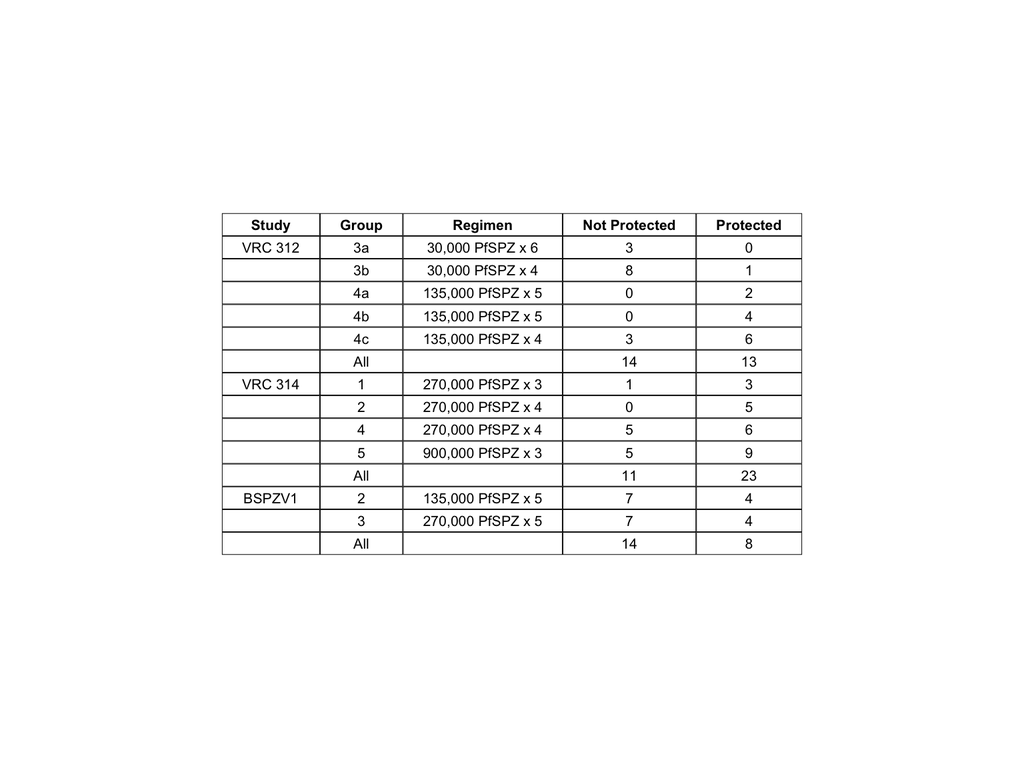

```r
study_tab <- data.frame(matrix(c("VRC 312", "3a", "30,000 PfSPZ x 6", "3", "0",
                           "", "3b", "30,000 PfSPZ x 4", "8", "1",
                           "", "4a", "135,000 PfSPZ x 5", "0", "2",
                           "", "4b", "135,000 PfSPZ x 5", "0", "4",
                           "", "4c", "135,000 PfSPZ x 4", "3", "6",
                           "", "All", "", "14", "13",
                           "VRC 314", "1", "270,000 PfSPZ x 3", "1", "3",
                           "", "2", "270,000 PfSPZ x 4", "0", "5",
                           "", "4", "270,000 PfSPZ x 4", "5", "6",
                           "", "5", "900,000 PfSPZ x 3", "5", "9",
                           "", "All", "", "11", "23",
                          "BSPZV1", "2", "135,000 PfSPZ x 5", "7", "4",
                          "", "3", "270,000 PfSPZ x 5", "7", "4",
                          "", "All", "", "14", "8"),
                          nrow = 14, byrow = T))
colnames(study_tab) <- c("Study", "Group","Regimen","Not Protected","Protected")
#for the Neal et al study (PMID 35031601), 3 subjects in BSPZV1 group 1who were smear negative throughout but PCR positive were considered protected

study_tab_plot <- ggtexttable(study_tab,
                                      rows = NULL,
                                      theme = ttheme("classic", base_size=8, padding = unit(c(8, 2.5), "mm")))

study_tab_plot
```

### Combine with BSPZV data and visualize GSEA data as bubble plot.

Filter based on padj < 0.05.

```r
#Get BSPZV1 Camera data from googledrive
temp <- tempfile(fileext = ".rds")
dl <- drive_download(
  as_id("1NF0IIJbFDMH_fjPnqS3yPRHb42ajXZug"), path = temp, overwrite = TRUE)
GSEAtab_BSPZV1 <- readRDS(file = dl$local_path)
```

```r
GSEA_BSPZV1_VRC312_VRC314 <- bind_rows(GSEAtab_VRC312,
                     GSEAtab_VRC314) %>%
  filter(module_type %in% c("highBTMs", "lowBTMs", "MonacoModules", "BloodGen3Module", "MSigDB_Hallmark_v7.4"))  %>%
  filter(!grepl("TBA", pathway)) %>%
  dplyr::select(study, module_type, pathway, leadingEdge, size, NES, padj) %>%
  mutate(neglogpadj = -log10(padj)) %>%
  dplyr::rename("BH-adj p value (FDR)" = "padj") %>%
  mutate(pathway = gsub("gd", "γδ", pathway)) %>%
  mutate(pathway = gsub("Vd2", "Vδ2", pathway)) %>%
  mutate(pathway = gsub("Vg", "Vγ", pathway)) %>%
  mutate(pathway = gsub("HALLMARK_", "", pathway)) %>%
  mutate(pathway = gsub("_", " ", pathway)) %>%
  mutate(pathway = sub(".*?\\_", "", pathway)) %>%
  filter(!grepl("TBD", pathway)) %>%
  mutate(module_type = factor(module_type, levels = c("highBTMs", "MonacoModules", "lowBTMs", "MSigDB_Hallmark_v7.4", "BloodGen3Module"))) %>%
  droplevels() %>%
  bind_rows(.,GSEAtab_BSPZV1) %>%
  mutate(study = factor(study, levels = c("VRC312", "VRC314", "BSPZV1"))) %>%
  arrange(study, module_type, desc(neglogpadj)) %>%
  group_by(module_type, study) %>%
  mutate(pathway = fct_reorder2(pathway, neglogpadj, desc(NES), .desc = FALSE)) %>%
  ungroup()
```

```r
#plotting options
basetextsize <- 7.5
myfont <- "Helvetica"
bubble_max_size <- 6

TopPlot <- GSEA_BSPZV1_VRC312_VRC314 %>%
  filter(`BH-adj p value (FDR)`<0.05) %>%
  filter(module_type %in% c("highBTMs", "MonacoModules"))  %>%
  ggplot(., aes(x = study, y = pathway)) +
  geom_point(aes(size=neglogpadj, fill = NES), alpha = 0.65, shape=21, stroke = 0.25) +
  scale_size_area(name = expression(-log[10]~adjp), max_size = bubble_max_size) +
      scale_fill_gradient2(low = "blue",
                           mid = "white",
                           high = "red") +
  hrbrthemes::theme_ipsum_es(base_family = myfont, base_size = basetextsize) +
  theme(axis.title.x = element_blank(),
        axis.title.y = element_blank(),
        strip.background = element_blank(),
        strip.text = element_text(size=5.5),
        legend.position = "right",
        axis.text.x = element_text(angle = 45, vjust = 1, hjust=1)) +
facet_wrap(~module_type, scales = "free_y", ncol =2)

TopPlot <- ggarrange(study_tab_plot ,addSmallLegend(TopPlot), widths = c(1,1))

Bottom_Left_Plot <- GSEA_BSPZV1_VRC312_VRC314 %>%
  filter(`BH-adj p value (FDR)`<0.05) %>%
  filter(module_type %in% c("lowBTMs"))  %>%
  ggplot(., aes(x = study, y = pathway)) +
  geom_point(aes(size=neglogpadj, fill = NES), alpha = 0.65, shape=21, stroke = 0.25) +
  scale_size_area(name = expression(-log[10]~adjp), max_size = bubble_max_size) +
      scale_fill_gradient2(low = "blue",
                           mid = "white",
                           high = "red") +
  hrbrthemes::theme_ipsum_es(base_family = myfont, base_size = basetextsize) +
  theme(axis.title.x = element_blank(),
        axis.title.y = element_blank(),
        strip.text = element_text(size=5.5),
        strip.background = element_blank(),
        legend.position = "right",
        axis.text.x = element_text(angle = 45, vjust = 1, hjust=1)) +
    theme(plot.margin = unit(c(1, 1, 5, 1), "cm")) +
facet_wrap(~module_type, scales = "free_y", nrow =2)

Bottom_Middle_Plot <- GSEA_BSPZV1_VRC312_VRC314 %>%
  filter(`BH-adj p value (FDR)`<0.05) %>%
  filter(module_type %in% c("MSigDB_Hallmark_v7.4"))  %>%
  ggplot(., aes(x = study, y = pathway)) +
  geom_point(aes(size=neglogpadj, fill = NES), alpha = 0.65, shape=21, stroke = 0.25) +
  scale_size_area(name = expression(-log[10]~adjp), max_size = bubble_max_size) +
      scale_fill_gradient2(low = "blue",
                           mid = "white",
                           high = "red") +
  hrbrthemes::theme_ipsum_es(base_family = myfont, base_size = basetextsize) +
  theme(axis.title.x = element_blank(),
        axis.title.y = element_blank(),
        strip.text = element_text(size=5.5),
        strip.background = element_blank(),
        legend.position = "right",
        axis.text.x = element_text(angle = 45, vjust = 1, hjust=1)) +
    theme(plot.margin = unit(c(1, 1.2, 10, 1.2), "cm")) +
facet_wrap(~module_type, scales = "free_y", nrow =2)


Bottom_Right_Plot <- GSEA_BSPZV1_VRC312_VRC314 %>%
  filter(`BH-adj p value (FDR)`<0.05) %>%
  filter(module_type %in% c("BloodGen3Module"))  %>%
  ggplot(., aes(x = study, y = pathway)) +
  geom_point(aes(size=neglogpadj, fill = NES), alpha = 0.65, shape=21, stroke = 0.25) +
  scale_size_area(name = expression(-log[10]~adjp), max_size = bubble_max_size) +
      scale_fill_gradient2(low = "blue",
                           mid = "white",
                           high = "red") +
  hrbrthemes::theme_ipsum_es(base_family = myfont, base_size = basetextsize) +
  theme(axis.title.x = element_blank(),
        axis.title.y = element_blank(),
        strip.text = element_text(size=5.5),
        strip.background = element_blank(),
        legend.position = "right",
        axis.text.x = element_text(angle = 45, vjust = 1, hjust=1))  +
    theme(plot.margin = unit(c(1, 1.75, 0.5, 1.75), "cm")) +
facet_wrap(~module_type, scales = "free_y", ncol =2)

bottom_panels <- ggarrange(addSmallLegend(Bottom_Left_Plot), addSmallLegend(Bottom_Middle_Plot), addSmallLegend(Bottom_Right_Plot),
                           widths = c(1.1, 1, 1),
                           ncol = 3,
                           common.legend = TRUE)
```

### Plot GSEA bubbleplots (Figures S4B of revised manuscript)

Red: enriched in protected/uninfected Blue: enriched in not protected/infected Only modules with BH-adjusted p value (FDR) < 0.05 are shown.

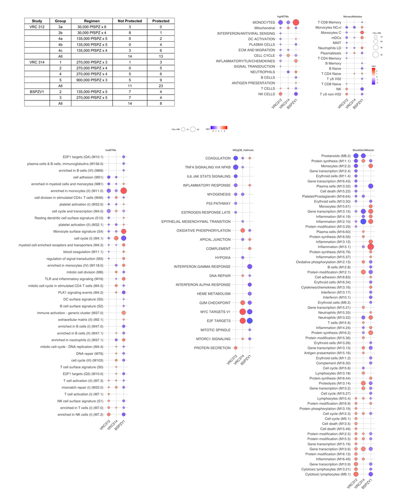

```r
ggarrange(addSmallLegend(TopPlot), bottom_panels, common.legend = TRUE, nrow = 2, heights = c(1,3))
```

```r
#Get BSPZV1 Camera data from googledrive
temp <- tempfile(fileext = ".rds")
dl <- drive_download(
  as_id("1NWQVtjpDP5Qjtee4aezR0fSywXpEn5fR"), path = temp, overwrite = TRUE)
myCameraPlotDat_BSPZV1 <- readRDS(file = dl$local_path)

Cameratab_BSPZV1_VRC312_VRC314 <- bind_rows(myCameraPlotDat_BSPZV1, myCameraPlotDat_VRC312, myCameraPlotDat_VRC314)
```

### Visualize Camera data as bubble plot

Filter based on padj < 0.05.

```r
#Red: enriched in protected/uninfected
#Blue: enriched in not protected/infected

plotDat_Camera <- Cameratab_BSPZV1_VRC312_VRC314 %>%
  mutate(study = factor(study, levels = c("VRC312", "VRC314", "BSPZV1"))) %>%
  mutate(enrichment = ifelse(Direction == "Up",
                           "up in protected/uninfected",
                           "up in not protected/infected")) %>%
  filter(FDR < 0.05) %>%
  filter(!grepl("TBA", module)) %>%
  mutate(neglogFDR = -log10(FDR)) %>%
  mutate(module = gsub("gd", "γδ", module)) %>%
  mutate(module = gsub("Vd2", "Vδ2", module)) %>%
  mutate(module = gsub("Vg", "Vγ", module)) %>%
  mutate(module = gsub("HALLMARK_", "", module)) %>%
  mutate(module = gsub("_", " ", module)) %>%
  mutate(module = sub(".*?\\_", "", module)) %>%
  filter(!grepl("TBD", module)) %>%
  arrange(desc(neglogFDR)) %>%
  group_by(study, module_type) %>%
  mutate(module = fct_reorder(module, neglogFDR, .desc = FALSE)) %>%
  ungroup() %>%
  droplevels()

#plotting options
basetextsize <- 7.5
myfont <- "Helvetica"
bubble_max_size <- 6

camera_hm_hibtm_monaco_plot <- plotDat_Camera %>%
  filter(module_type %in% c("MSigDB_Hallmark_v7.4", "highBTMs", "MonacoModules")) %>%
  mutate(module_type = factor(module_type,
                              levels = c("highBTMs", "MonacoModules", "MSigDB_Hallmark_v7.4"),
                              labels = c("high BTMs", "Monaco", "Hallmark"))) %>%
  ggplot(., aes(x = study, y = module, fill = enrichment)) +
  geom_point(aes(size=neglogFDR), shape=21, stroke = 0.25, alpha = 0.6) +
  scale_size_area(name = expression(-log[10]~FDR), max_size = bubble_max_size) +
  scale_fill_manual(values = c("blue","red")) +
  hrbrthemes::theme_ipsum_es(base_family = myfont, base_size = basetextsize) +
  theme(axis.title.x = element_blank(),
        axis.title.y = element_blank(),
        strip.text = element_text(size = 5.5),
        strip.background = element_blank(),
        legend.position = "none",
        axis.text.x = element_text(angle = 45, vjust = 1, hjust=1)) +
  facet_wrap(~module_type, scales = "free_y", nrow = 3)

module_summary_lowbtms <- plotDat_Camera %>%
  group_by(module_type, module) %>%
  summarize(n = n()) %>%
  filter(module_type == "lowBTMs" & n>1) %>%
  arrange(n)

camera_lowbtm_plot <- plotDat_Camera %>%
  filter(module_type %in% c("lowBTMs")) %>%
  filter(module %in% module_summary_lowbtms$module) %>%
  ggplot(., aes(x = study, y = module, fill = enrichment)) +
  geom_point(aes(size=neglogFDR), shape=21, stroke = 0.25, alpha = 0.6) +
  scale_size_area(name = expression(-log[10]~FDR), max_size = bubble_max_size) +
  scale_fill_manual(values = c("blue","red")) +
  #ggtitle("low BTMs") +
  hrbrthemes::theme_ipsum_es(base_family = myfont, base_size = basetextsize) +
  theme(axis.title.x = element_blank(),
        axis.title.y = element_blank(),
        strip.text = element_text(size = 5.5),
        legend.position = "right",
        axis.text.x = element_text(angle = 45, vjust = 1, hjust=1)) +
  facet_wrap(~module_type)

module_summary_BloodGen3Module <- plotDat_Camera %>%
  group_by(module_type, module) %>%
  summarize(n = n()) %>%
  filter(module_type == "BloodGen3Module" & n>1) %>%
  arrange(n)

camera_bloodgen3_plot <- plotDat_Camera %>%
  filter(module_type %in% c("BloodGen3Module")) %>%
  filter(module %in% module_summary_BloodGen3Module$module) %>%
  ggplot(., aes(x = study, y = module, fill = enrichment)) +
  geom_point(aes(size=neglogFDR), shape=21, stroke = 0.25, alpha = 0.6) +
  scale_size_area(name = expression(-log[10]~FDR), max_size = bubble_max_size) +
  scale_fill_manual(values = c("blue","red")) +
  #ggtitle("low BTMs") +
  hrbrthemes::theme_ipsum_es(base_family = myfont, base_size = basetextsize) +
  theme(axis.title.x = element_blank(),
        axis.title.y = element_blank(),
        strip.text = element_text(size = 5.5),
        legend.position = "right",
        axis.text.x = element_text(angle = 45, vjust = 1, hjust=1)) +
  facet_wrap(~module_type)
```

### Plot Camera bubbleplots

Red: enriched in protected/uninfected Blue: enriched in not protected/infected

Only modules with FDR<5% are shown.

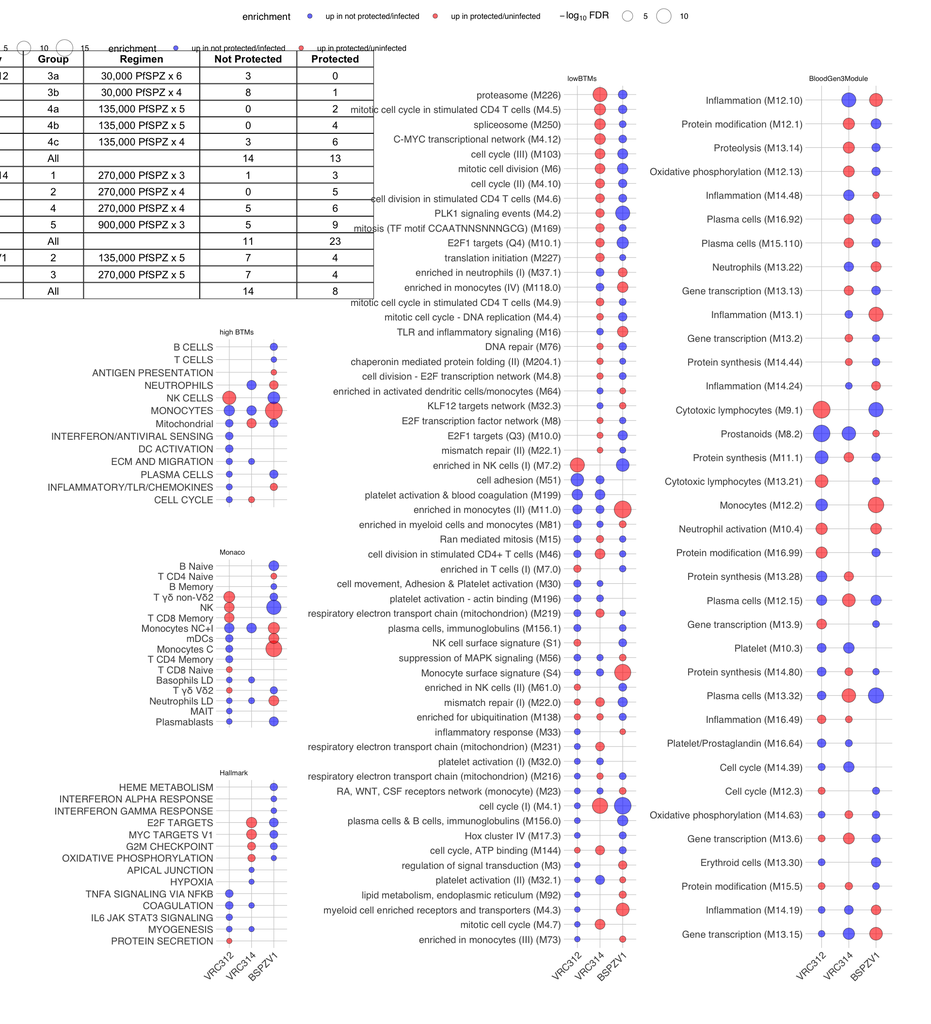

```r
#addSmallLegend(camera_hibtms_plot)
tab_hm_hibtm_monaco_plot <- ggpubr::ggarrange(study_tab_plot, camera_hm_hibtm_monaco_plot, nrow=2, heights = c(0.3,1), widths = c(0.5,1), common.legend = TRUE)
ggpubr::ggarrange(tab_hm_hibtm_monaco_plot, ggplot() + theme_void(), camera_lowbtm_plot, ggplot() + theme_void(), camera_bloodgen3_plot,
                  ncol = 5, widths = c(0.77, -0.175, 1, -0.175, 0.78), common.legend = TRUE)
```